# Ethnicity and Identity

Data Management

Michael Foley

2022-02-01

The [American Trends Panel Wave 77](https://www.pewresearch.org/social-trends/dataset/american-trends-panel-wave-77/) data set is available for download at the PEW Research web site. This data was collected from a survey conducted Oct. 13-19, 2020. Everyone who took part is a member of the Pew Research Center’s American Trends Panel (ATP), an online survey panel that is recruited through national, random sampling of residential addresses. The survey is weighted to be representative of the U.S. adult population by gender, race, ethnicity, partisan affiliation, education and other categories ([ATP methodology](https://www.pewresearch.org/methods/u-s-survey-research/american-trends-panel/)).

```r
dat_0 <- foreign::read.spss(
  "../data/ATP W77.sav",
  to.data.frame = TRUE
)

svy_0 <- svydesign(ids = ~1, weights = ~ WEIGHT_W77, data = dat_0)
```

The data set consists of 138 variables collected from 10,332 participants. Only a fraction of the columns are of interest for this analysis.

I did not find a codebook associated with the descriptive fields, so I’m going to have to infer a bit. The questions and associated variable names are in the questionanaire.

## Demographics

Most demographic variables are self-explanatory from the variable name or from the response options. A few need explanation.

- `XKIDS1_W77`: PARENTS OF CHILDREN UNDER 18.
- `XPARENT_W77`: PARENTS OF CHILDREN UNDER 18 *LIVING IN HOUSEHOLD* (*No* could mean they are not parents of children under 18, or they are parents of children under 18 but the children are not living in in the household.)

```r
svy_0 %>% gtsummary::tbl_svysummary(
  include = c(starts_with("X"), starts_with("F_"), E_COVID_W77,
              E_COVIDPARTNER_W77, WFHCURR_W77, WFHPARTNERCURR_W77,
              WFHPOSTCVD_W77, CHILD_LT12_W77))
```

| **Characteristic** | **N = 10,332**<sup>1</sup> |
| --- | --- |
| XMARITAL_W77 |  |
| Has spouse or partner | 6,376 (62%) |
| Does not have spouse or partner | 3,956 (38%) |
| XKIDS1_W77 |  |
| Yes | 3,074 (30%) |
| No | 7,219 (70%) |
| Refused | 38 (0.4%) |
| XPARENT_W77 |  |
| Yes | 2,817 (27%) |
| No | 7,468 (72%) |
| Refused | 47 (0.5%) |
| F_METRO |  |
| Metropolitan | 8,957 (87%) |
| Non-metropolitan | 1,375 (13%) |
| F_CREGION |  |
| Northeast | 1,817 (18%) |
| Midwest | 2,142 (21%) |
| South | 3,923 (38%) |
| West | 2,450 (24%) |
| F_CDIVISION |  |
| New England | 548 (5.3%) |
| Middle Atlantic | 1,269 (12%) |
| East North Central | 1,442 (14%) |
| West North Central | 700 (6.8%) |
| South Atlantic | 2,061 (20%) |
| East South Central | 605 (5.9%) |
| West South Central | 1,256 (12%) |
| Mountain | 830 (8.0%) |
| Pacific | 1,620 (16%) |
| F_AGECAT |  |

[output cut: 216 more lines]

<sup>*1*</sup> n (%)

## Questions

You can read all of the questions and response options in the questionnaire. I am particularly interested in questions related to how spouses share family responsibilities.

### `FAMSURV1`

> At this point in your life, which of the following would be best for you personally?

```r
svy_0 %>%
  subset(E_COVID_W77 %in% c("Employed full-time", "Employed part-time")) %>%
  tbl_svysummary(by = "F_GENDER", include = "FAMSURV1_W77", percent = "col")
```

| **Characteristic** | **A man**, N = 3,022<sup>1</sup> | **A woman**, N = 2,776<sup>1</sup> | **In some other way**, N = 54<sup>1</sup> | **Refused**, N = 19<sup>1</sup> |
| --- | --- | --- | --- | --- |
| FAMSURV1_W77 |  |  |  |  |
| Working full-time for pay | 2,438 (81%) | 1,926 (69%) | 31 (57%) | 4 (21%) |
| Working part-time for pay | 520 (17%) | 779 (28%) | 21 (40%) | 14 (75%) |
| Not working for pay at all | 62 (2.1%) | 70 (2.5%) | 2 (2.9%) | 1 (4.0%) |
| Refused | 2 (<0.1%) | 2 (<0.1%) | 0 (0%) | 0 (0%) |

<sup>*1*</sup> n (%)

### `FAMSURV32`

> How do you feel about each of the following?
> - `FAMSURV32_a_W77`: The way household chores are divided between you and your spouse or partner
> - `FAMSURV32_c_W77`: How well you and your spouse or partner communicate with each other
> - `FAMSURV32_d_W77`: How well your spouse or partner balances work and their personal life
> - `FAMSURV32_e_W77`: Your spouse or partner’s approach to parenting

```r
svy_0 %>%
  subset(E_COVID_W77 %in% c("Employed full-time", "Employed part-time")) %>%
  tbl_svysummary(by = "F_GENDER", include = starts_with("FAMSURV32"), percent = "col")
```

| **Characteristic** | **A man**, N = 3,022<sup>1</sup> | **A woman**, N = 2,776<sup>1</sup> | **In some other way**, N = 54<sup>1</sup> | **Refused**, N = 19<sup>1</sup> |
| --- | --- | --- | --- | --- |
| FAMSURV32_a_W77 |  |  |  |  |
| Very satisfied | 1,092 (54%) | 624 (36%) | 6 (26%) | 1 (24%) |
| Somewhat satisfied | 687 (34%) | 576 (34%) | 5 (21%) | 1 (23%) |
| Somewhat dissatisfied | 165 (8.1%) | 316 (18%) | 13 (53%) | 3 (53%) |
| Very dissatisfied | 86 (4.2%) | 194 (11%) | 0 (0%) | 0 (0%) |
| Refused | 5 (0.2%) | 5 (0.3%) | 0 (0%) | 0 (0%) |
| Unknown | 987 | 1,062 | 30 | 13 |
| FAMSURV32_c_W77 |  |  |  |  |
| Very satisfied | 939 (46%) | 711 (41%) | 8 (34%) | 1 (24%) |
| Somewhat satisfied | 799 (39%) | 613 (36%) | 14 (60%) | 4 (76%) |
| Somewhat dissatisfied | 206 (10%) | 250 (15%) | 2 (6.5%) | 0 (0%) |
| Very dissatisfied | 86 (4.2%) | 135 (7.9%) | 0 (0%) | 0 (0%) |
| Refused | 4 (0.2%) | 5 (0.3%) | 0 (0%) | 0 (0%) |
| Unknown | 987 | 1,062 | 30 | 13 |
| FAMSURV32_d_W77 |  |  |  |  |
| Very satisfied | 662 (49%) | 567 (41%) | 7 (31%) | 2 (34%) |
| Somewhat satisfied | 488 (36%) | 559 (40%) | 13 (57%) | 1 (12%) |
| Somewhat dissatisfied | 169 (12%) | 176 (13%) | 2 (8.5%) | 2 (54%) |
| Very dissatisfied | 40 (2.9%) | 84 (6.0%) | 1 (2.9%) | 0 (0%) |
| Refused | 2 (0.1%) | 5 (0.4%) | 0 (0%) | 0 (0%) |
| Unknown | 1,661 | 1,386 | 31 | 14 |
| FAMSURV32_e_W77 |  |  |  |  |
| Very satisfied | 537 (59%) | 309 (41%) | 0 (0%) | 0 (0%) |
| Somewhat satisfied | 268 (29%) | 297 (39%) | 5 (78%) | 1 (18%) |
| Somewhat dissatisfied | 80 (8.8%) | 122 (16%) | 1 (22%) | 2 (82%) |
| Very dissatisfied | 27 (2.9%) | 27 (3.5%) | 0 (0%) | 0 (0%) |
| Refused | 1 (0.2%) | 0 (<0.1%) | 0 (0%) | 0 (0%) |
| Unknown | 2,109 | 2,021 | 47 | 16 |

<sup>*1*</sup> n (%)

### `FAMSURV35`

> Since the beginning of the coronavirus outbreak, have you personally experienced the following because you were balancing work and parenting responsibilities?
> - `FAMSURV35_a_W77`: Needed to reduce your work hours
> - `FAMSURV35_b_W77`: Felt like you couldn’t give 100% at work
> - `FAMSURV35_c_W77`: Turned down a promotion
> - `FAMSURV35_d_W77`: Turned down an important assignment at work

```r
svy_0 %>%
  subset(E_COVID_W77 %in% c("Employed full-time", "Employed part-time")) %>%
  tbl_svysummary(by = "F_GENDER", include = starts_with("FAMSURV35"), percent = "col")
```

| **Characteristic** | **A man**, N = 3,022<sup>1</sup> | **A woman**, N = 2,776<sup>1</sup> | **In some other way**, N = 54<sup>1</sup> | **Refused**, N = 19<sup>1</sup> |
| --- | --- | --- | --- | --- |
| FAMSURV35_a_W77 |  |  |  |  |
| Yes, have experienced this | 263 (27%) | 327 (34%) | 7 (59%) | 0 (0%) |
| No, have not experienced this | 728 (73%) | 631 (66%) | 5 (41%) | 3 (100%) |
| Refused | 1 (<0.1%) | 1 (<0.1%) | 0 (0%) | 0 (0%) |
| Unknown | 2,031 | 1,818 | 41 | 16 |
| FAMSURV35_b_W77 |  |  |  |  |
| Yes, have experienced this | 430 (43%) | 519 (54%) | 12 (95%) | 0 (0%) |
| No, have not experienced this | 561 (57%) | 439 (46%) | 1 (5.4%) | 3 (100%) |
| Refused | 1 (<0.1%) | 1 (0.1%) | 0 (0%) | 0 (0%) |
| Unknown | 2,031 | 1,818 | 41 | 16 |
| FAMSURV35_c_W77 |  |  |  |  |
| Yes, have experienced this | 32 (3.2%) | 88 (9.2%) | 0 (0%) | 0 (0%) |
| No, have not experienced this | 959 (97%) | 865 (90%) | 12 (100%) | 3 (100%) |
| Refused | 1 (<0.1%) | 5 (0.5%) | 0 (0%) | 0 (0%) |
| Unknown | 2,031 | 1,818 | 41 | 16 |
| FAMSURV35_d_W77 |  |  |  |  |
| Yes, have experienced this | 111 (11%) | 140 (15%) | 5 (42%) | 0 (0%) |
| No, have not experienced this | 879 (89%) | 818 (85%) | 7 (58%) | 3 (100%) |
| Refused | 2 (0.2%) | 0 (0%) | 0 (0%) | 0 (0%) |
| Unknown | 2,031 | 1,818 | 41 | 16 |

<sup>*1*</sup> n (%)

### `FAMSURV36`

> Since the beginning of the coronavirus outbreak, have you personally experienced the following at work because you have children?
> - `FAMSURV36_a_W77`: Being passed over for a promotion
> - `FAMSURV36_b_W77`: Being passed over for an important assignment
> - `FAMSURV36_c_W77`: Being treated as if you weren’t committed to your work

```r
svy_0 %>%
  subset(E_COVID_W77 %in% c("Employed full-time", "Employed part-time")) %>%
  tbl_svysummary(by = "F_GENDER", include = starts_with("FAMSURV36"), percent = "col")
```

| **Characteristic** | **A man**, N = 3,022<sup>1</sup> | **A woman**, N = 2,776<sup>1</sup> | **In some other way**, N = 54<sup>1</sup> | **Refused**, N = 19<sup>1</sup> |
| --- | --- | --- | --- | --- |
| FAMSURV36_a_W77 |  |  |  |  |
| Yes, have experienced this | 44 (4.4%) | 87 (9.1%) | 0 (0%) | 0 (0%) |
| No, have not experienced this | 946 (95%) | 871 (91%) | 12 (100%) | 3 (100%) |
| Refused | 2 (0.2%) | 1 (<0.1%) | 0 (0%) | 0 (0%) |
| Unknown | 2,031 | 1,818 | 41 | 16 |
| FAMSURV36_b_W77 |  |  |  |  |
| Yes, have experienced this | 83 (8.3%) | 108 (11%) | 0 (0%) | 0 (0%) |
| No, have not experienced this | 907 (91%) | 850 (89%) | 12 (100%) | 3 (100%) |
| Refused | 2 (0.2%) | 1 (<0.1%) | 0 (0%) | 0 (0%) |
| Unknown | 2,031 | 1,818 | 41 | 16 |
| FAMSURV36_c_W77 |  |  |  |  |
| Yes, have experienced this | 108 (11%) | 177 (19%) | 5 (44%) | 0 (0%) |
| No, have not experienced this | 873 (88%) | 781 (81%) | 7 (56%) | 3 (100%) |
| Refused | 10 (1.0%) | 1 (<0.1%) | 0 (0%) | 0 (0%) |
| Unknown | 2,031 | 1,818 | 41 | 16 |

<sup>*1*</sup> n (%)

### `FAMSURV38`

> For each of the following, who would you say does more?
> - `FAMSURV38_a_W77`: Household chores and responsibilities
> - `FAMSURV38_b_W77`: Managing household finances
> - `FAMSURV38_c_W77`: Managing your child(ren)’s schedule and activities
> - `FAMSURV38_d_W77`: Being an involved parent

```r
svy_0 %>%
  subset(E_COVID_W77 %in% c("Employed full-time", "Employed part-time")) %>%
  tbl_svysummary(by = "F_GENDER", include = starts_with("FAMSURV38"), percent = "col")
```

| **Characteristic** | **A man**, N = 3,022<sup>1</sup> | **A woman**, N = 2,776<sup>1</sup> | **In some other way**, N = 54<sup>1</sup> | **Refused**, N = 19<sup>1</sup> |
| --- | --- | --- | --- | --- |
| FAMSURV38_a_W77 |  |  |  |  |
| You do more than your spouse or partner | 396 (19%) | 984 (57%) | 17 (70%) | 4 (76%) |
| Your spouse or partner does more than you | 720 (35%) | 124 (7.2%) | 2 (6.7%) | 1 (9.0%) |
| Both about equally | 915 (45%) | 600 (35%) | 6 (24%) | 1 (15%) |
| Refused | 4 (0.2%) | 6 (0.4%) | 0 (0%) | 0 (0%) |
| Unknown | 987 | 1,062 | 30 | 13 |
| FAMSURV38_b_W77 |  |  |  |  |
| You do more than your spouse or partner | 1,037 (51%) | 851 (50%) | 13 (56%) | 1 (9.6%) |
| Your spouse or partner does more than you | 455 (22%) | 367 (21%) | 5 (20%) | 4 (76%) |
| Both about equally | 537 (26%) | 491 (29%) | 6 (24%) | 1 (15%) |
| Refused | 6 (0.3%) | 4 (0.2%) | 0 (0%) | 0 (0%) |
| Unknown | 987 | 1,062 | 30 | 13 |
| FAMSURV38_c_W77 |  |  |  |  |
| You do more than your spouse or partner | 76 (8.4%) | 518 (69%) | 5 (78%) | 2 (82%) |
| Your spouse or partner does more than you | 508 (56%) | 35 (4.7%) | 0 (7.3%) | 1 (18%) |
| Both about equally | 327 (36%) | 201 (27%) | 1 (14%) | 0 (0%) |
| Refused | 1 (0.1%) | 0 (<0.1%) | 0 (0%) | 0 (0%) |
| Unknown | 2,109 | 2,021 | 47 | 16 |
| FAMSURV38_d_W77 |  |  |  |  |
| You do more than your spouse or partner | 66 (7.2%) | 369 (49%) | 1 (15%) | 0 (0%) |
| Your spouse or partner does more than you | 275 (30%) | 27 (3.6%) | 0 (0%) | 0 (0%) |
| Both about equally | 572 (63%) | 357 (47%) | 6 (85%) | 3 (100%) |
| Refused | 1 (0.1%) | 2 (0.2%) | 0 (0%) | 0 (0%) |
| Unknown | 2,109 | 2,021 | 47 | 16 |

<sup>*1*</sup> n (%)

### `TIMEOFF`

> Some companies have given working parents additional time off to deal with disruptions caused by the coronavirus outbreak. Do you think this is…

```r
svy_0 %>%
  subset(E_COVID_W77 %in% c("Employed full-time", "Employed part-time")) %>%
  tbl_svysummary(by = "F_GENDER", include = "TIMEOFF_W77", percent = "col")
```

| **Characteristic** | **A man**, N = 3,022<sup>1</sup> | **A woman**, N = 2,776<sup>1</sup> | **In some other way**, N = 54<sup>1</sup> | **Refused**, N = 19<sup>1</sup> |
| --- | --- | --- | --- | --- |
| TIMEOFF_W77 |  |  |  |  |
| Unfair because workers who do not have children end up having to do more work | 515 (17%) | 445 (16%) | 7 (12%) | 12 (63%) |
| Fair because parents are dealing with demands at home that other workers do not have | 2,478 (82%) | 2,288 (82%) | 47 (88%) | 6 (34%) |
| Refused | 30 (1.0%) | 43 (1.6%) | 0 (0%) | 1 (3.0%) |

<sup>*1*</sup> n (%)

### `TIMECHILD`

> Thinking about the time *you* spend with your CHILDREN these days, do you think you spend…

```r
svy_0 %>%
  subset(E_COVID_W77 %in% c("Employed full-time", "Employed part-time")) %>%
  tbl_svysummary(by = "F_GENDER", include = "TIMECHILD_W77", percent = "col")
```

| **Characteristic** | **A man**, N = 3,022<sup>1</sup> | **A woman**, N = 2,776<sup>1</sup> | **In some other way**, N = 54<sup>1</sup> | **Refused**, N = 19<sup>1</sup> |
| --- | --- | --- | --- | --- |
| TIMECHILD_W77 |  |  |  |  |
| Too MUCH time | 56 (5.0%) | 84 (8.2%) | 2 (11%) | 0 (0%) |
| Too LITTLE time | 529 (47%) | 416 (41%) | 6 (47%) | 0 (0%) |
| The right amount of time | 521 (47%) | 514 (50%) | 6 (41%) | 3 (100%) |
| Refused | 13 (1.1%) | 11 (1.1%) | 0 (0%) | 0 (0%) |
| Unknown | 1,904 | 1,751 | 40 | 16 |

<sup>*1*</sup> n (%)

### `TIMESPOUSE`

> Thinking about the time you spend with your SPOUSE OR PARTNER these days, do you think you spend…

```r
svy_0 %>%
  subset(E_COVID_W77 %in% c("Employed full-time", "Employed part-time")) %>%
  tbl_svysummary(by = "F_GENDER", include = "TIMESPOUSE_W77", percent = "col")
```

| **Characteristic** | **A man**, N = 3,022<sup>1</sup> | **A woman**, N = 2,776<sup>1</sup> | **In some other way**, N = 54<sup>1</sup> | **Refused**, N = 19<sup>1</sup> |
| --- | --- | --- | --- | --- |
| TIMESPOUSE_W77 |  |  |  |  |
| Too MUCH time | 174 (8.6%) | 154 (9.0%) | 2 (6.7%) | 0 (0%) |
| Too LITTLE time | 816 (40%) | 662 (39%) | 17 (70%) | 2 (44%) |
| The right amount of time | 1,038 (51%) | 885 (52%) | 6 (24%) | 3 (56%) |
| Refused | 6 (0.3%) | 13 (0.7%) | 0 (0%) | 0 (0%) |
| Unknown | 987 | 1,062 | 30 | 13 |

<sup>*1*</sup> n (%)

### `CHILDHOME`

> Do you have any child care responsibilities when you’re working from home?

```r
svy_0 %>%
  subset(E_COVID_W77 %in% c("Employed full-time", "Employed part-time")) %>%
  tbl_svysummary(by = "F_GENDER", include = "CHILDHOME_W77", percent = "col")
```

| **Characteristic** | **A man**, N = 3,022<sup>1</sup> | **A woman**, N = 2,776<sup>1</sup> | **In some other way**, N = 54<sup>1</sup> | **Refused**, N = 19<sup>1</sup> |
| --- | --- | --- | --- | --- |
| CHILDHOME_W77 |  |  |  |  |
| A lot | 55 (15%) | 112 (34%) | 0 (0%) | 0 (0%) |
| Some | 181 (49%) | 105 (32%) | 0 (43%) | 0 (0%) |
| Not much | 105 (28%) | 67 (20%) | 0 (0%) | 1 (100%) |
| None at all | 27 (7.5%) | 43 (13%) | 1 (57%) | 0 (0%) |
| Refused | 0 (0%) | 2 (0.5%) | 0 (0%) | 0 (0%) |
| Unknown | 2,654 | 2,448 | 52 | 18 |

<sup>*1*</sup> n (%)

### `CVDBALANCE`

> Compared with before the coronavirus outbreak, is it…

```r
svy_0 %>%
  subset(E_COVID_W77 %in% c("Employed full-time", "Employed part-time")) %>%
  tbl_svysummary(by = "F_GENDER", include = "CVDBALANCE_W77", percent = "col")
```

| **Characteristic** | **A man**, N = 3,022<sup>1</sup> | **A woman**, N = 2,776<sup>1</sup> | **In some other way**, N = 54<sup>1</sup> | **Refused**, N = 19<sup>1</sup> |
| --- | --- | --- | --- | --- |
| CVDBALANCE_W77 |  |  |  |  |
| Easier for you to balance work and family responsibilities | 447 (16%) | 353 (14%) | 2 (4.5%) | 0 (0%) |
| Harder for you to balance work and family responsibilities | 693 (24%) | 760 (30%) | 26 (48%) | 3 (40%) |
| About the same | 1,715 (60%) | 1,440 (56%) | 25 (47%) | 5 (60%) |
| Refused | 1 (<0.1%) | 6 (0.2%) | 0 (0%) | 0 (0%) |
| Unknown | 166 | 217 | 0 | 11 |

<sup>*1*</sup> n (%)

### `CVCHILDCARE`

> How easy or difficult has it been for you to handle child care responsibilities during the coronavirus outbreak?

```r
svy_0 %>%
  subset(E_COVID_W77 %in% c("Employed full-time", "Employed part-time")) %>%
  tbl_svysummary(by = "F_GENDER", include = "CVCHILDCARE_W77", percent = "col")
```

| **Characteristic** | **A man**, N = 3,022<sup>1</sup> | **A woman**, N = 2,776<sup>1</sup> | **In some other way**, N = 54<sup>1</sup> | **Refused**, N = 19<sup>1</sup> |
| --- | --- | --- | --- | --- |
| CVCHILDCARE_W77 |  |  |  |  |
| Very easy | 133 (17%) | 105 (16%) | 4 (35%) | 0 (0%) |
| Somewhat easy | 276 (36%) | 181 (27%) | 1 (9.6%) | 1 (18%) |
| Somewhat difficult | 279 (36%) | 272 (40%) | 1 (11%) | 0 (0%) |
| Very difficult | 84 (11%) | 119 (18%) | 5 (45%) | 0 (0%) |
| Refused | 0 (0%) | 1 (<0.1%) | 0 (0%) | 2 (82%) |
| Unknown | 2,250 | 2,099 | 43 | 16 |

<sup>*1*</sup> n (%)

### `WLBALANCE1`

> How difficult, if at all, would you say it is for you personally to balance the responsibilities of your job with the responsibilities of your family?

```r
svy_0 %>%
  subset(E_COVID_W77 %in% c("Employed full-time", "Employed part-time")) %>%
  tbl_svysummary(by = "F_GENDER", include = "WLBALANCE1_W77", percent = "col")
```

| **Characteristic** | **A man**, N = 3,022<sup>1</sup> | **A woman**, N = 2,776<sup>1</sup> | **In some other way**, N = 54<sup>1</sup> | **Refused**, N = 19<sup>1</sup> |
| --- | --- | --- | --- | --- |
| WLBALANCE1_W77 |  |  |  |  |
| Very easy | 129 (12%) | 115 (12%) | 1 (9.4%) | 0 (0%) |
| Somewhat easy | 496 (45%) | 345 (35%) | 2 (12%) | 0 (0%) |
| Somewhat difficult | 423 (39%) | 409 (41%) | 8 (58%) | 3 (100%) |
| Very difficult | 46 (4.2%) | 121 (12%) | 3 (20%) | 0 (0%) |
| Refused | 1 (0.1%) | 9 (0.9%) | 0 (0%) | 0 (0%) |
| Unknown | 1,927 | 1,778 | 40 | 16 |

<sup>*1*</sup> n (%)

## Exploration: Validation with Reports

Pew produced several reports from this survey. To make sure I understand the data correctly, this section reproduces some of their important results.

In [A rising share of working parents in the U.S. say it’s been difficult to handle child care during the pandemic](https://www.pewresearch.org/fact-tank/2021/01/26/a-rising-share-of-working-parents-in-the-u-s-say-its-been-difficult-to-handle-child-care-during-the-pandemic/), Pew writes

> Overall, about half of employed parents with children younger than 12 in the household (52%) say it has been difficult to handle child care responsibilities during the coronavirus outbreak… Both working mothers and fathers with children younger than 12 are more likely than they were earlier in the pandemic to say it’s been difficult to handle child care responsibilities. But as was the case in March, larger shares of mothers than fathers say this (57% vs. 47%).

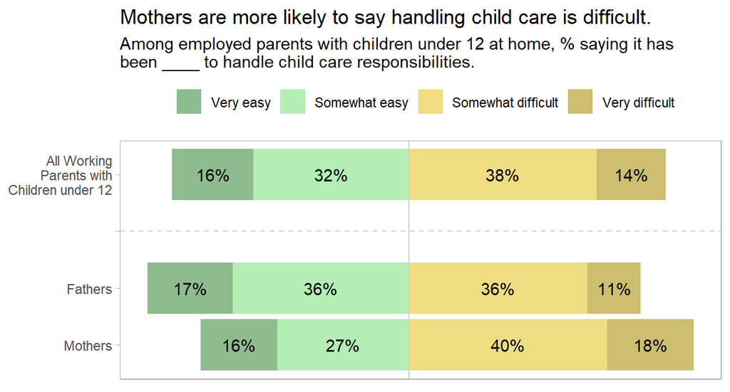

```r
freq_by_gender <- function(dat, freq_var) {
  dat %>%
    group_by(F_GENDER, !!sym(freq_var)) %>%
    summarize(.groups = "drop", wt = sum(WEIGHT_W77), n = n()) %>%
    group_by(F_GENDER) %>%
    mutate(pct = wt / sum(wt)) %>%
    ungroup()
}

dat_working_parent <- dat_0 %>%
  filter(
    E_COVID_W77 %in% c("Employed full-time", "Employed part-time") &
      CHILD_LT12_W77 == "Yes" &
      F_GENDER %in% c("A man", "A woman")
  )

fig1_dat <- dat_working_parent %>%
  filter(CVCHILDCARE_W77 != "Refused") %>%
  freq_by_gender("CVCHILDCARE_W77")

fig1_total <- dat_working_parent %>%
  filter(CVCHILDCARE_W77 != "Refused") %>%
  mutate(F_GENDER = "(total)") %>%
  freq_by_gender("CVCHILDCARE_W77")

fig1_na <- fig1_total %>% mutate(F_GENDER = "NA", pct = NA_real_)

palette_easy <- c("darkseagreen", "darkseagreen2", "lightgoldenrod", "lightgoldenrod3", "#FFFFFF")
names(palette_easy) <- levels(dat_0$CVCHILDCARE_W77)

bind_rows(fig1_dat, fig1_total, fig1_na) %>%
  mutate(F_GENDER = factor(F_GENDER, levels = c("(total)", "NA", "A man", "A woman"),
                           labels = c("All Working Parents with Children under 12",
                                      " ", "Fathers", "Mothers")),
         CVCHILDCARE_W77 = fct_relevel(CVCHILDCARE_W77, "Somewhat difficult", after = 3)) %>%
  ggplot(aes(x = if_else(str_detect(CVCHILDCARE_W77, "easy"), -pct, +pct),
             y = fct_rev(F_GENDER),
             fill = CVCHILDCARE_W77)) +
  geom_col() +
  geom_text(aes(label = percent(pct, 1)), position = position_stack(vjust = .5)) +
  geom_hline(yintercept = " ", linetype = 2, color = "lightgray") +
  geom_vline(xintercept = 0, linetype = 1, color = "lightgray") +
  scale_fill_manual(values = palette_easy[1:4]) +
  scale_y_discrete(labels = wrap_format(18)) +
  theme_light() +
  theme(legend.position = "top",
        panel.grid = element_blank(),
        axis.text.x = element_blank(),
        axis.ticks.x = element_blank()) +
  labs(x = NULL, y = NULL, fill = NULL,
       title = "Mothers are more likely to say handling child care is difficult.",
       subtitle = str_wrap("Among employed parents with children under 12 at home, % saying it has been ____ to handle child care responsibilities.", 70))
```

## Save Data

Save the refined data set to a file for subsequent steps.

```r
saveRDS(dat_0, "../data/1_data_mgmt.rds")
```